# Visibility

Adela Sobotkova

2022-12-14

## Purpose and prerequisites:

This script serves to elaborate the calculation of mutual intervisibility (clear line of sight) between various archaeological features, starting here with burial mounds in the Yambol Region and ASTER elevation raster (30m spatial resolution).

The script basically works, calculating linestrings, intervisibility between Yam_mounds and generating maps

You need: - to run 09 BA mounds to have the necessary libraries and digital objects

## Load 2009-2022 data

```r
Y_elev <- raster("../output_data/large/Yelev32635.tif")
# Yambol mounds
Yam_mnds <- readRDS("../output_data/Yam_mnds.rds")
head(Yam_mnds)
```

```
## Simple feature collection with 6 features and 18 fields
## Geometry type: POINT
## Dimension:     XY
## Bounding box:  xmin: 452997 ymin: 4706447 xmax: 454596 ymax: 4707823
## Projected CRS: WGS 84 / UTM zone 35N
## # A tibble: 6 × 19
##    TRAP Source      Type  LU_Ar…¹ LU_Top Diame…² Heigh…³ Condi…⁴ Princ…⁵ distB…⁶
##   <dbl> <chr>       <chr> <chr>   <chr>    <dbl>   <dbl> <fct>   <chr>       [m]
## 1  9411 Survey      Buri… Scrub   Scrub       15     1.5 2       Nodata   61029.
## 2  9416 Legacy ver… Buri… Annual… Annua…      20     2   3       Agricu…  62183.
## 3  9417 Legacy ver… Buri… Pasture Pastu…      15     2   4       Looting  62265.
## 4  9409 Legacy ver… Buri… Annual… Pastu…      30     2   2       Agricu…  61453.
## 5  9314 Legacy ver… Buri… Pasture Pastu…      30     2   5       Looting  60783.
## 6  9315 Legacy ver… Buri… Pasture Pastu…      20     1   2       Looting  60718.
## # … with 9 more variables: distTown [m], elevAster <dbl>, slopeAster <dbl>,
## #   aspectAster <dbl>, prom250mbuff <dbl>, TPI <dbl>, TRI <dbl>, rough <dbl>,
## #   geometry <POINT [m]>, and abbreviated variable names ¹LU_Around,
## #   ²DiameterMax, ³HeightMax, ⁴Condition, ⁵PrincipalSourceOfImpact, ⁶distBG[,1]
```

# Bronze Age mounds from Toshko

Drazhevo - Height: 2.7 m; Diameter: 37.0 m; Land: pasture on the rocky area Straldzha - Height: 4.0 m; Diameter: 50.0 m; Land: wines and pasture Popovo - Height: 6.8 m; Diameter: 48.0 m; Land: wines and pasture

8345 Mogila village - Height: 3.2 m; Diameter: 37.6 m; Land: pasture on the rocky area

## Linestring creation

Let’s first see if we an create linestrings to later signal which mounds can *see* each other.

```r
# Test linestring creation from one origin and multiple target points. The coords object needs to be a matrix, but to cbind one to many coordinates the component columns need to be dataframes.
coords <- as.matrix(cbind(as.data.frame(st_coordinates(extrasf$geometry[2])),
                as.data.frame(st_coordinates(BApoints$geometry))))

lines_sm <-  st_sfc(
     lapply(1:nrow(coords),
           function(i){
             st_linestring(matrix(coords[i,],ncol=2,byrow=TRUE))
           }))

st_crs(lines_sm) <- st_crs(BApoints)


library(mapview)
mapview(lines_sm)+mapview(BApoints)
```

[interactive chart not shown]

```r
# https://stackoverflow.com/questions/65498300/how-to-efficiently-create-linestrings-from-points
# https://stackoverflow.com/questions/58150279/plotting-lines-between-two-sf-point-features-in-r
```

## Intervisibility

Intervisibility in human terms mean that two or more points in the landscape have a clear line of sight between them (given reasonable visibility). In computational terms, it means that a straight line connecting the z values of the A and B (the two end-points) does not intersect a polygon formed by terrain profile between them. If it doesn’t, A can see B. Let’s test such line of sight by extracting data out of raster cells between our BA points.

https://stackoverflow.com/questions/21841387/r-code-that-evaluates-line-of-sight-los-between-two-lat-lon-points

https://gis.stackexchange.com/questions/272122/performing-viewshed-analysis-in-r

```r
cansee <- function(r, xy1, xy2, h1=0, h2=0){
### can xy1 see xy2 on DEM r?
### Y_elev is a DEM in same x,y, z units
### xy1 and xy2 are 2-length vectors of x,y coords
### h1 and h2 are extra height offsets
###  (eg top of mast, observer on a ladder etc)
    xyz = rasterprofile(r, xy1, xy2)
    np = nrow(xyz)-1
    h1 = xyz$z[1] + h1
    h2 = xyz$z[np] + h2
    hpath = h1 + (0:np)*(h2-h1)/np
    return(!any(hpath < xyz$z))
}



viewTo <- function(r, xy, xy2, h1=0, h2=0, progress="none"){
    ## xy2 is a matrix of x,y coords (not a data frame)
    require(dplyr)
    apply(xy2, 1, function(d){cansee(r,xy,d,h1,h2)}, .progress=progress)
}

viewTo <- function(r, xy, xy2, h1=0, h2=0){
    ## xy2 is a matrix of x,y coords (not a data frame)
    require(dplyr)
    apply(xy2, 1, function(d){cansee(r,xy,d,h1,h2)})
}

rasterprofile <- function(r, xy1, xy2){
### sample a raster along a straight line between two points
### try to match the sampling size to the raster resolution
    dx = sqrt( (xy1[1]-xy2[1])^2 + (xy1[2]-xy2[2])^2 )
    nsteps = 1 + round(dx/ min(res(r)))
    xc = xy1[1] + (0:nsteps) * (xy2[1]-xy1[1])/nsteps
    yc = xy1[2] + (0:nsteps) * (xy2[2]-xy1[2])/nsteps
    data.frame(x=xc, y=yc, z=r[cellFromXY(r,cbind(xc,yc))])
}
```

Let’s test these with real data (BA points 8346, 8007 and Drazhevo)

```r
BApoints[c(3,6,10),]
```

```
## Simple feature collection with 3 features and 19 fields
## Geometry type: POINT
## Dimension:     XY
## Bounding box:  xmin: 455442 ymin: 4681159 xmax: 469481.6 ymax: 4710935
## Projected CRS: WGS 84 / UTM zone 35N
##      TRAP              Source         Type LU_Around  LU_Top DiameterMax
## X3   8007              survey Burial Mound   Pasture Pasture          15
## X6   8346 Legacy verification Burial Mound   Pasture Pasture          21
## X1.1   NA          Excavation Burial Mound   Pasture    <NA>          37
##      HeightMax Condition         PrincipalSourceOfImpact       distBG
## X3         4.5         1 Post-depositional | Development 33549.70 [m]
## X6         1.0         2               Post-depositional 59506.54 [m]
## X1.1       2.7      <NA>                            <NA>       NA [m]
##          distTown elevAster slopeAster aspectAster prom250mbuff       TPI
## X3   2100.386 [m]  211.4289   4.158135    21.73105        96.77 0.6661510
## X6   2230.781 [m]  167.3124   4.360649   336.51962        95.29 0.1345997
## X1.1       NA [m]        NA         NA          NA           NA        NA
##           TRI    rough    place                 geometry
## X3   1.757505 5.214966     <NA> POINT (469481.6 4681159)
## X6   1.779181 5.737717     <NA> POINT (464400.3 4706954)
## X1.1       NA       NA Drazhevo   POINT (455442 4710935)
```

```r
m8007 <- c(st_coordinates(BApoints)[3,],h= BApoints$HeightMax[3])
m8346 <- c(st_coordinates(BApoints)[6,],h= BApoints$HeightMax[6])
mDrazh<- c(st_coordinates(BApoints)[10,],h= BApoints$HeightMax[10])

Y_elev
```

```
## class      : RasterLayer
## dimensions : 2780, 2990, 8312200  (nrow, ncol, ncell)
## resolution : 23, 30.8  (x, y)
## extent     : 431411, 500181, 4641688, 4727312  (xmin, xmax, ymin, ymax)
## crs        : +proj=utm +zone=35 +datum=WGS84 +units=m +no_defs
## source     : Yelev32635.tif
## names      : Yelev32635
## values     : 49.21985, 588.9428  (min, max)
```

```r
test_see <- cansee(Y_elev, m8007, m8346, h1 = m8007[3]  , h2 = m8346[3])
test_see
```

```
## [1] FALSE
```

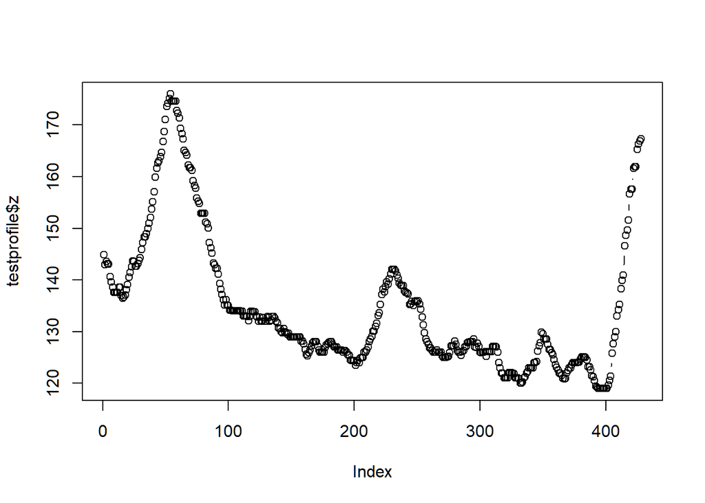

```r
# Create a terrain profile and plot it to check potential intervisibility
testprofile <- rasterprofile(Y_elev,  m8007, m8346)
testprofile <- rasterprofile(Y_elev,  m8007, mDrazh)
testprofile <- rasterprofile(Y_elev,  mDrazh, m8346)

# Plot
plot(testprofile$z, type = "b");
```

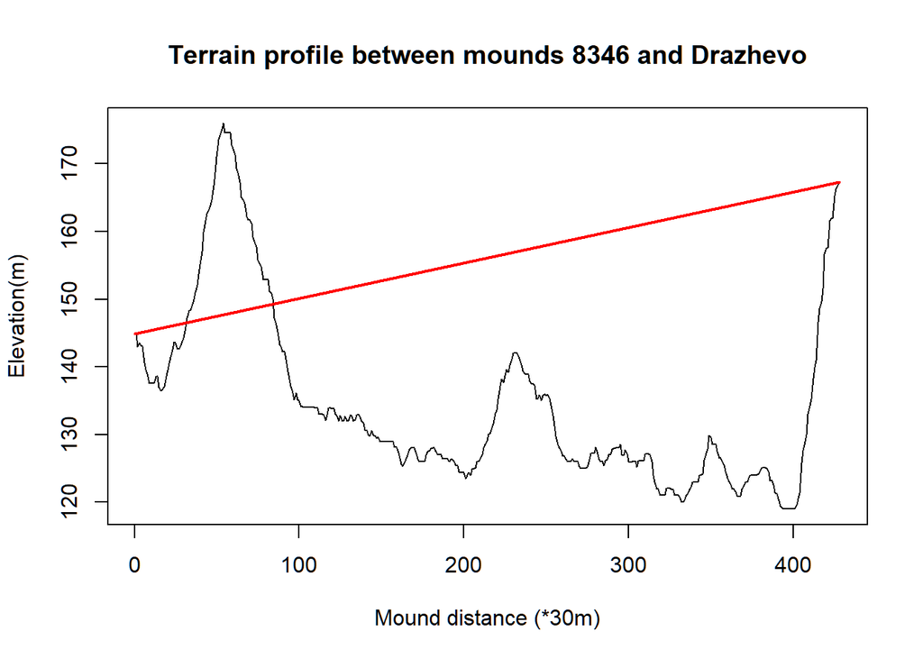

```r
# create the connecting line between origin and destination points
x = c(0,nrow(testprofile))
y = testprofile$z[c(1,nrow(testprofile))]

# Plot profile with start and end point elevation
plot(testprofile$z, type = "l", main = "Terrain profile between mounds 8346 and Drazhevo",
     ylab = "Elevation(m)", xlab = "Mound distance (*30m)");
lines(x,y, col = "red", lwd = 2)
```

None of these mounds can see each other, because the one on top of the Zaichi Vrah is obscured by the hill and not aimed at the mounds to the SE. Let’s test the intervisibility between these three and other mounds in the surroundings from the Yambol Mounds dataset. We will use the viewTo() function and the starting coordinates of the three mounds.

```r
# First we need to convert the Yambol mounds to a matrix of coordinates
coords <- data.frame(st_coordinates(Yam_mnds),h=Yam_mnds$HeightMax)
missingHeight <- which(is.na(coords$h))
mnd_missH <- Yam_mnds$TRAP[missingHeight]

coords <- coords %>%
  filter(!is.na(h))
coords_m <- as.matrix(coords)

# viewTo() working with 3 points
testview <- viewTo(Y_elev, m8007, rbind(m8346,mDrazh))

# with all points (uncomment if you wish to regenerate!)
# testview <- viewTo(Y_elev, m8007, coords_m,m8007[3], coords_m[,3])
# length(testview)


# # See which ones can see 8007
# '%nin%' = Negate('%in%')
# viewTo_8007 <- Yam_mnds %>%
#   filter(TRAP %nin% mnd_missH) %>%   # must first filter away missing heights as I did with coordinates
#   filter(testview) # use the logical vector to filter the Yam_mnds rows

# 289 mounds can see mound 8007
# saveRDS(viewTo_8007, "../output_data/MoundsVisfrom8007.rds")
viewTo_8007 <- readRDS("../output_data/MoundsVisfrom8007.rds")
```

View these 289 mounds visible from 8007

```r
# Test linestring creation from one origin and multiple target points. The coords object needs to be a matrix, but to cbind one to many coordinates the component columns need to be dataframes.
coords <- as.matrix(cbind(rep(m8007[1], 289),rep(m8007[2], 289), st_coordinates(viewTo_8007)))

lines <-  st_sfc(
     lapply(1:nrow(coords),
           function(i){
             st_linestring(matrix(coords[i,],ncol=2,byrow=TRUE))
           }))

st_crs(lines) <- st_crs(BApoints)

library(mapview)
library(leafsync)
m1 <- mapview(lines) + mapview(viewTo_8007, cex = 4) + mapview(BApoints[3,], cex = 10)
m2 <- mapview(viewTo_8007, zcol = "prom250mbuff")
sync(m1,m2)
```

[interactive chart not shown]